# AULA 1

### Variáveis Numéricas

#### Variável int

```python
a = 10
```

```python
b = 20
```

```python
a + b
```

```
30
```

```python
type(a+b)
```

```
int
```

#### Variável float

```python
c = 2.5
```

```python
type(c)
```

```
float
```

#### Variável string

```python
nome = 'Geraldo'
```

```python
nome
```

```
'Geraldo'
```

```python
type(nome)
```

```
str
```

#### Variável do tipo booleana

```python
#variáveis lógicas que retornam TRUE ou FALSE

n1 = 3
n2 = 4
```

```python
n1 > n2
```

```
False
```

```python
n1 < n2
```

```
True
```

# AULA 2

### Operações com Variáveis

#### soma

```python
10 + 15
```

```
25
```

```python
a=4
b=6
```

```python
a + b
```

```
10
```

```python
10.75 + 9.25
```

```
20.0
```

#### subtração

```python
sub = 50 - 17
```

```python
sub
```

```
33
```

```python
a = 74
b = 33
```

```python
a-b
```

```
41
```

```python
c = 1.89
d = 0.56
```

```python
c - d
```

```
1.3299999999999998
```

#### multiplicação

```python
mult = 4 * 3
```

```python
mult
```

```
12
```

```python
a = 5
b = 8
```

```python
a * b
```

```
40
```

#### divisão

```python
div = 10 / 5
```

```python
div
```

```
2.0
```

```python
a = 4
b = 2
```

```python
a / b
```

```
2.0
```

#### divisão inteira (exibe a parte inteira de uma divisão)

```python
div_inteira = 3 // 2
```

```python
div_inteira
```

```
1
```

#### exponenciação

```python
exp = 5**2
```

```python
exp
```

```
25
```

#### resto da divisão (Mod)

```python
mod = 5 % 2
```

```python
mod
```

```
1
```

```python
6 % 3
```

```
0
```

# AULA 3

### Operadores e conectivos

#### Maior

```python
a = 5 > 6
```

```python
a
```

```
False
```

#### Menor

```python
b = 4 < 5
```

```python
b
```

```
True
```

#### Maior ou Igual

```python
5 >= 4
```

```
True
```

```python
5 >= 5
```

```
True
```

```python
5 >= 6
```

```
False
```

#### Menor ou Igual

```python
4 <= 6
```

```
True
```

```python
4 <= 4
```

```
True
```

```python
4 <= 2
```

```
False
```

#### Igual

```python
4 == 4
```

```
True
```

```python
4 == 3
```

```
False
```

#### Diferente

```python
4 != 5
```

```
True
```

```python
4 != 4
```

```
False
```

#### Conectivo AND

```python
a = 4 < 5 and 4 < 6
```

```python
a
```

```
True
```

```python
a = 4 < 5 and 4 < 3
```

```python
a
```

```
False
```

#### Conectivo OR

```python
a = 4 < 5 or 4 < 3
```

```python
a
```

```
True
```

#### Conectivo NOT

```python
a = 4 < 5
```

```python
a
```

```
True
```

```python
a = not 4 < 5
```

```python
a
```

```
False
```

# AULA 4

### IF - ELSE - ELIF

```python
idade = 15
```

```python
if(idade>=18):
    print('Pode tirar CNH')
else:
    print('Não pode tirar CHN')
```

```
Não pode tirar CHN
```

```python
idade_Joao = 19
idade_Maria = 20
```

```python
if(idade_Joao>idade_Maria):
    print('João é mais velho que Maria')
else:
    print('Maria é mais velha que João')
```

```
Maria é mais velha que João
```

```python
idade_Joao = 19
idade_Maria = 20
idade_Pedro = 23
```

```python
if(idade_Joao>idade_Maria and idade_Joao>idade_Pedro):
    print('João é o mais velho de todos')
elif(idade_Maria>idade_Joao and idade_Maria>idade_Pedro):
    print('Maria é a mais velha de todos')
else:
    print('Pedro é o mais velho de todos')
```

```
Pedro é o mais velho de todos
```

```python
#criança, adolescente, adulto e idoso
```

```python
idade = 35
```

```python
if(idade <= 13):
    print('Criança')
elif(idade >= 14 and idade < 18):
    print('Adolescente')
elif(idade >= 18 and idade < 60):
    print('Adulto')
else:
    print('Idoso')
```

```
Adulto
```

# AULA 4.1

### Indentação

```python
a = 5
b = 4
```

```python
# Indentação correta:
```

```python
if(a > b):
    print('a é maior que b')
else:
    print('b é maior que a')
```

```
a é maior que b
```

```python
# Indentação incorreta:
```

```python
if(a > b):
print('a é maior que b')
else:
print('b é maior que a')
```

```
  File "<ipython-input-85-dcf78f57cd75>", line 2
    print('a é maior que b')
        ^
IndentationError: expected an indented block
```

```python
# O Python se preocupa muito com a indentação, se os blocos ou linhas de comandos não estiverem alinhados dará erro.
```

# AULA 5

### Listas

```python
A = [1, 2, 3, 4]
```

```python
A
```

```
[1, 2, 3, 4]
```

```python
# Aceita valores de diversos tipos:
```

```python
B = [1, 2, 'Olá', 2.5, True]
```

```python
B
```

```
[1, 2, 'Olá', 2.5, True]
```

```python
# As listas são ordenados pelos seus índices, e inicia no zero
```

No índice 0 da variável B está o valor 1 No índice 1 da variável B está o valor 2 No índice 2 da variável B está o valor 'Olá' ... E assim por diante

podemos utilizar índices negativos também onde

- -1 é o último item da lista
- -2 é o penúltimo item da lista
- -3 é o antepenúltimo item da lista... etc

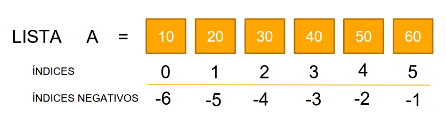

```python
frutas = ['maçã', 'laranja', 'banana', 'abacaxi']
```

```python
frutas
```

```
['maçã', 'laranja', 'banana', 'abacaxi']
```

```python
type(frutas)
```

```
list
```

```python
# acessando itens na lista
```

```python
frutas[2]
```

```
'banana'
```

```python
frutas[0]
```

```
'maçã'
```

```python
frutas[1:3] # O último valor do índice informado NÃO entra no intervalo
```

```
['laranja', 'banana']
```

```python
frutas = ['maçã', 'laranja', 'banana', 'abacaxi', 'abacate', 'limão']
```

```python
frutas
```

```
['maçã', 'laranja', 'banana', 'abacaxi', 'abacate', 'limão']
```

```python
# quero laranja, banana e abacaxi:
```

```python
frutas[1:4]
```

```
['laranja', 'banana', 'abacaxi']
```

```python
frutas[2:]
```

```
['banana', 'abacaxi', 'abacate', 'limão']
```

```python
frutas[:5]
```

```
['maçã', 'laranja', 'banana', 'abacaxi', 'abacate']
```

```python
frutas[-1]
```

```
'limão'
```

```python
frutas[-2]
```

```
'abacate'
```

```python
frutas[-3]
```

```
'abacaxi'
```

```python
lista = ['sim','não','sim','não','sim','não']
```

```python
lista[:]  # os dois pontos exibe a lista toda
```

```
['sim', 'não', 'sim', 'não', 'sim', 'não']
```

```python
lista[0:7]
```

```
['sim', 'não', 'sim', 'não', 'sim', 'não']
```

```python
lista[0:7:2] # O último valor determina o passo de seleção da lista, no exemplo ele percorre os índices 0, 2 e 4.
```

```
['sim', 'sim', 'sim']
```

```python
lista[::2] # Outra forma de escrever o mesmo comando do exemplo acima
```

```
['sim', 'sim', 'sim']
```

```python
# testando se um valor está na lista:
```

```python
frutas
```

```
['maçã', 'laranja', 'banana', 'abacaxi', 'abacate', 'limão']
```

```python
'maçã' in frutas
```

```
True
```

```python
'melancia' in frutas
```

```
False
```

```python
# Podemos também concatenar listas
```

```python
frutas2 = ['melancia', 'morango', 'manga']
```

```python
frutas2
```

```
['melancia', 'morango', 'manga']
```

```python
frutas3 = frutas + frutas2
```

```python
frutas3
```

```
['maçã',
 'laranja',
 'banana',
 'abacaxi',
 'abacate',
 'limão',
 'melancia',
 'morango',
 'manga']
```

```python
# listas dentro de listas
```

```python
lista = [1, 2, 3, 'alvo', 20]
```

```python
lista[3]
```

```
'alvo'
```

```python
lista = [1, 2, 3, [10, 'alvo', 15], 18, 20]
```

```python
lista
```

```
[1, 2, 3, [10, 'alvo', 15], 18, 20]
```

```python
lista[3]
```

```
[10, 'alvo', 15]
```

```python
lista[3][1]
```

```
'alvo'
```

```python
lista = [1, 2, 3, [10,2, [2, 4, 'alvo']], 25, 23]
```

```python
lista
```

```
[1, 2, 3, [10, 2, [2, 4, 'alvo']], 25, 23]
```

```python
lista[3][2][2]
```

```
'alvo'
```

```python
# Como alterar valores de uma lista
```

```python
lista = [2, 4, 6, 8]
```

```python
lista[1]=5
```

```python
lista
```

```
[2, 5, 6, 8]
```

```python
lista[:] = ['mudei', 'mudei', 'mudei', 'mudei']
```

```python
lista
```

```
['mudei', 'mudei', 'mudei', 'mudei']
```

```python
# Atribuindo e excluindo valores
```

```python
lista = [2, 4, 6, 8]
```

```python
lista.append(10) # Adiciona valor na última posição da lista
```

```python
lista
```

```
[2, 4, 6, 8, 10]
```

```python
del(lista[2])
```

```python
lista
```

```
[2, 4, 8, 10]
```

# AULA 6

### Tuplas

```python
# As tuplas são basicamente listas imutáveis. Armazenam valores mas não podemos adicionar ou remover valores
```

```python
lista = [1, 2, 3, 4]
```

```python
tupla = (1, 2, 3, 4)
```

```python
del(lista[2])
```

```python
lista
```

```
[1, 2, 4]
```

```python
lista.append(100)
```

```python
lista
```

```
[1, 2, 4, 100]
```

```python
tupla.append(100)
```

```
---------------------------------------------------------------------------
AttributeError                            Traceback (most recent call last)
<ipython-input-158-81ce3824746a> in <module>
----> 1 tupla.append(100)

AttributeError: 'tuple' object has no attribute 'append'
```

```python
del(tupla[2])
```

```
---------------------------------------------------------------------------
TypeError                                 Traceback (most recent call last)
<ipython-input-159-e627f5007c9f> in <module>
----> 1 del(tupla[2])

TypeError: 'tuple' object doesn't support item deletion
```

```python
# Acessar os valores de uma tupla utiliza EXATAMENTE o mesmo procedimento/comandos da lista
```

# AULA 7

### Dicionários

Os dados em um dicionário não são acessados por índices e sim por CHAVES

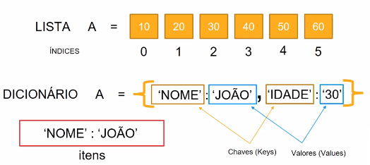

```python
cadastro = { 'nome':'João', 'idade':30, 'sexo':'masculino' }
```

```python
cadastro
```

```
{'nome': 'João', 'idade': 30, 'sexo': 'masculino'}
```

```python
type(cadastro)
```

```
dict
```

```python
cadastro['nome']
```

```
'João'
```

```python
cadastro['idade']
```

```
30
```

```python
# Métodos do dicionário
```

```python
'João' in cadastro
```

```
False
```

```python
'João' in cadastro.values()
```

```
True
```

```python
'nome' in cadastro
```

```
True
```

```python
'nome'in cadastro.keys()
```

```
True
```

```python
('nome', 'João') in cadastro.items()
```

```
True
```

```python
# Alterando valores do dicionário
```

```python
cadastro['nome'] = 'Pedro'
```

```python
cadastro
```

```
{'nome': 'Pedro', 'idade': 30, 'sexo': 'masculino'}
```

```python
# Adicionar Valores
```

```python
cadastro['altura'] = 1.75
```

```python
cadastro
```

```
{'nome': 'Pedro', 'idade': 30, 'sexo': 'masculino', 'altura': 1.75}
```

```python
# Remover Valores
```

```python
del(cadastro['sexo'])
```

```python
cadastro
```

```
{'nome': 'Pedro', 'idade': 30, 'altura': 1.75}
```

```python
# Copiando dicionários
```

```python
cadastro
```

```
{'nome': 'Pedro', 'idade': 30, 'altura': 1.75}
```

```python
cadastro_igual = cadastro     # MÉTODO 1
```

```python
cadastro_igual
```

```
{'nome': 'Pedro', 'idade': 30, 'altura': 1.75}
```

```python
copia = cadastro.copy()       # MÉTODO 2
```

```python
copia
```

```
{'nome': 'Pedro', 'idade': 30, 'altura': 1.75}
```

```python
# Qual a diferença em criar pelo MÉTODO 1 ou pelo MÉTODO 2 ?


# MÉTODO 1 -  Se eu fizer uma alteração no dicionário original então sua cópia também será alterada.
# MÉTODO 2 -  Cria uma cópia que não é alterada se ocorrer mudanças no dicionário original.
```

```python
# Juntando dicionários
```

```python
meus_contatos = {'Geraldo':'9999-9999', 'Vanessa':'8888-8888', 'Carla':'7777-7777'}
```

```python
seus_contatos = {'Rafaela':'6666-6666', 'Luiza':'5555-5555', 'Bia':'4444-4444'}
```

```python
meus_contatos.update(seus_contatos)
```

```python
meus_contatos
```

```
{'Geraldo': '9999-9999',
 'Vanessa': '8888-8888',
 'Carla': '7777-7777',
 'Rafaela': '6666-6666',
 'Luiza': '5555-5555',
 'Bia': '4444-4444'}
```

# AULA 8

### While

while (condição):

```
bloco de ação

iterador
```

```python
cont = 1

while(cont <= 50):
    print(cont)
    cont = cont +1
```

```
1
2
3
4
5
6
7
8
9
10
11
12
13
14
15
16
17
18
19
20
21
22
23
24
25
26
27
28
29
30
31
32
33
34
35
36
37
38
39
40
41
42
43
44
45
46
47
48
49
50
```

```python
# BREAK
```

```python
cont = 0

while(cont <= 10):
    print(cont)
    cont = cont+1
```

```
0
1
2
3
4
5
6
7
8
9
10
```

```python
cont = 0

while(cont <= 10):
    print(cont)
    if(cont == 7):
        break
    cont = cont+1
```

```
0
1
2
3
4
5
6
7
```

```python
# Continue -  Esse método faz com que a ação do while não seja realizada e o programa retorne ao loop
```

```python
cont = 0

while(cont < 10):
    cont = cont+1
    if(cont == 7):
        continue
    print(cont)
```

```
1
2
3
4
5
6
8
9
10
```

```python
#No caso acima quando cont = 7 o método faz com que o loop continue sem executar a ação seguinte, que no caso seria: print(cont)
# O método pula o bloco de ação ( print(cont) ) e volta para o início do laço while
```

# AULA 9

### For

============================================================================================================

for x in range (0,16)

```
print(x)
```

============================================================================================================

Em palavras: Para cada valor (x) no intervalo de 0 a 16 ( in range (0,16) ), realize essa ação ( print(x) )

============================================================================================================

Iria sem exibido: 0,1,2,3,4,5,6,7,8,9,10,11,12,13,14,15

!!! Lembrando que o último valor, no caso 16, não entra.

```python
# Loop in range
```

```python
for valor in range (0,21):
    print(valor)
```

```
0
1
2
3
4
5
6
7
8
9
10
11
12
13
14
15
16
17
18
19
20
```

```python
# Loop em uma lista
```

```python
frutas = ['maçã', 'banana', 'abacaxi', 'melão', 'morango']
```

```python
frutas
```

```
['maçã', 'banana', 'abacaxi', 'melão', 'morango']
```

```python
for x in frutas:
    print(x)
```

```
maçã
banana
abacaxi
melão
morango
```

```python
# Loop em dicionário
```

```python
cadastro = {'nome':'João', 'idade':62, 'sexo':'masculino'}
```

```python
cadastro
```

```
{'nome': 'João', 'idade': 62, 'sexo': 'masculino'}
```

```python
for chave in cadastro:
    print(chave)
```

```
nome
idade
sexo
```

```python
for valor in cadastro.values():
    print(valor)
```

```
João
62
masculino
```

```python
for chave,valor in cadastro.items():
    print(chave,valor)
```

```
nome João
idade 62
sexo masculino
```

```python
# Loop em Tuplas
```

```python
tupla = (1, 2, 3, 4, 5, 6)
```

```python
tupla
```

```
(1, 2, 3, 4, 5, 6)
```

```python
for elemento in tupla:
    print(elemento)
```

```
1
2
3
4
5
6
```

```python
# break
```

```python
for valor in range(0,10):
    print(valor)
```

```
0
1
2
3
4
5
6
7
8
9
```

```python
for valor in range(0,10):
    if(valor == 7):
        break
    print(valor)
```

```
0
1
2
3
4
5
6
```

```python
# comtinue
```

```python
for valor in range(0,21):
    print(valor)
```

```
0
1
2
3
4
5
6
7
8
9
10
11
12
13
14
15
16
17
18
19
20
```

```python
for valor in range(0,21):
    if(valor == 5 or valor == 10 or valor == 15 or valor == 20):
        continue
    print(valor)
```

```
0
1
2
3
4
6
7
8
9
11
12
13
14
16
17
18
19
```

# AULA 10

### Funções

```python
lista = [10,43,12,45,57]
```

```python
lista
```

```
[10, 43, 12, 45, 57]
```

```python
maior = 0

for elemento in lista:
    if elemento > maior:
        maior = elemento
print(maior)
```

```
57
```

```python
max(lista)
```

```
57
```

```python
# Definindo uma função que multiplique um número qualquer por dois
```

```python
def vezes_dois(a):
    c = a*2
    return c
```

```python
type(vezes_dois)
```

```
function
```

```python
vezes_dois(4)
```

```
8
```

```python
vezes_dois(4829)
```

```
9658
```

LAMBDA - Método simplificado de criar funções

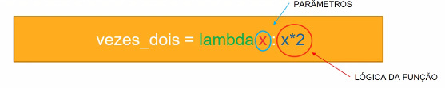

```python
# Criando a mesma função acima:
```

```python
vezes_dois = lambda x:x*2
```

```python
vezes_dois(3)
```

```
6
```

```python
lista = [405, 2003, 784, 2890, 105]
```

```python
max(lista)
```

```
2890
```

```python
min(lista)
```

```
105
```

```python
len(lista)
```

```
5
```

```python
type(lista)
```

```
list
```

```python
def tr():                         # Função sem input de parâmetros
    traços = print('-='*50)
    return traços
```

```python
tr()
```

[output not shown]

```python
salarios = [1290,3250,2890,4130,1540]
```

Suponhamos que haverá reajuste salarial de 25%

Função MAP é um método que percorre todos os valores de um iterável (lista,tuplas,dicionários) realizando uma ação em cada valor.

Possui a estrutura: map(função,iterável)

A função pode ser passada para o map de duas maneiras:

```python
# 1º Maneira - Função método tradicional:
```

```python
def vezes_vc (x):
    y = x + (x*0.25)
    return y
```

```python
salarios_reajustados = map(vezes_vc,salarios)
```

```python
print(list(salarios_reajustados))   # A função list() transforma variáveis em lista
```

```
[1612.5, 4062.5, 3612.5, 5162.5, 1925.0]
```

```python
# 2º Maneira - Função Lambda
```

```python
salarios
```

```
[1290, 3250, 2890, 4130, 1540]
```

```python
salarios_reajustados = map(lambda x: x+(x*0.25), salarios)
```

```python
print(list(salarios_reajustados))
```

```
[1612.5, 4062.5, 3612.5, 5162.5, 1925.0]
```

# AULA 11

### Numpy Arrays

Numpy é uma biblioteca de Álgebra Linar pra Python e foi a partir dela que praticamente todas as outras bibliotecas para análise de dados pro Python foram criadas.

O Numpy são baseados em arrays que são estruturas para guardar dados.

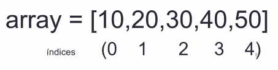

#### Arrays armazenam apenas valores numéricos

```python
import numpy as np
```

```python
# criar um array a partir de uma lista
```

```python
qtde = [2, 5, 10, 20, 35]
custo = [100, 150, 450, 320, 195]
```

```python
arr1 = np.array(qtde)
```

```python
arr2 = np.array(custo)
```

```python
arr1
```

```
array([ 2,  5, 10, 20, 35])
```

```python
arr2
```

```
array([100, 150, 450, 320, 195])
```

```python
estoque = qtde*custo   #Não posso multiplicar listas
```

```
---------------------------------------------------------------------------
TypeError                                 Traceback (most recent call last)
<ipython-input-99-4887f08445e8> in <module>
----> 1 estoque = qtde*custo

TypeError: can't multiply sequence by non-int of type 'list'
```

```python
estoque = arr1*arr2
```

```python
estoque
```

```
array([ 200,  750, 4500, 6400, 6825])
```

#### Como visto acima, não poderíamos multiplicar os valores correspondentes entre duas LISTAS, porém com ARRAY isso é possível !

```python
custo = [100, 200, 300, 400]
venda = [125, 235, 355, 490]
```

```python
arr3 = np.array(custo)
arr4 = np.array(venda)
```

```python
lucro = arr4-arr3
```

```python
lucro
```

```
array([25, 35, 55, 90])
```

```python
# Arrays a partir do Numpy

# 1. ARANGE
```

```python
np.arange(10,20)
```

```
array([10, 11, 12, 13, 14, 15, 16, 17, 18, 19])
```

```python
np.arange(10,21,2)
```

```
array([10, 12, 14, 16, 18, 20])
```

```python
np.arange(10,101,2,dtype=float)
```

```
array([ 10.,  12.,  14.,  16.,  18.,  20.,  22.,  24.,  26.,  28.,  30.,
        32.,  34.,  36.,  38.,  40.,  42.,  44.,  46.,  48.,  50.,  52.,
        54.,  56.,  58.,  60.,  62.,  64.,  66.,  68.,  70.,  72.,  74.,
        76.,  78.,  80.,  82.,  84.,  86.,  88.,  90.,  92.,  94.,  96.,
        98., 100.])
```

```python
# 2. Linspace - Utilizado para criar arrays com numeros definidos de elementos. Cada elemento é igualmente espaçado entre eles
```

```python
np.linspace(0,1,10)     #Array indo de 0 até 1 com 10 elementos
```

```
array([0.        , 0.11111111, 0.22222222, 0.33333333, 0.44444444,
       0.55555556, 0.66666667, 0.77777778, 0.88888889, 1.        ])
```

```python
np.linspace(1,10,10)    #Array indo de 1 até 10 com 10 elementos
                        #Como determinei que teria 10 elementos então o Numpy adicionou o 10 também, porque senão iria até o 9.
```

```
array([ 1.,  2.,  3.,  4.,  5.,  6.,  7.,  8.,  9., 10.])
```

# AULA 11.1

### Numpy Arrays (continuação...)

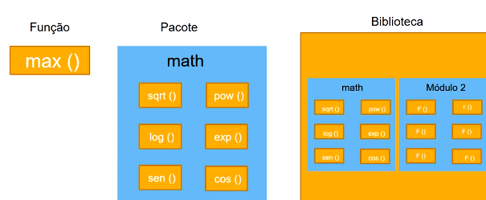

##### Numpy é uma biblioteca que contém módulos e esses módulos contém funções. A estrutura pra chamar uma função existente no Numpy é: numpy.módulo.função

##### Pressionando ' Shift+Tab ' com o cursor dentro dos parênteses de uma função é exibido um " guia " de como os parâmetros devem ser inseridos.

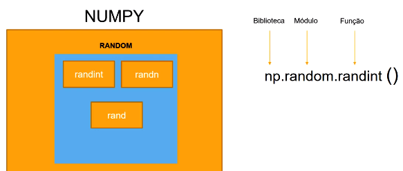

Módulo Random // funções de Random: rand, randn, randint, etc

```python
# rand   -   Cria um Array que gera uma distribuição uniforme, basicamente gera números aleatórios entre 0 e 1
```

```python
np.random.rand(10)   # O parâmetro de rand indica o número de valores do array
```

```
array([0.00464323, 0.11652793, 0.66225162, 0.49704407, 0.71012037,
       0.65530593, 0.71825902, 0.68219958, 0.08368673, 0.74001167])
```

```python
# randn   -   Retorna um array que segue uma DISTRIBUIÇÃO NORMAL com média zero e variância 1.
```

```python
np.random.randn(15)
```

```
array([ 1.51514496,  0.40076206, -0.40167317, -0.44622683,  1.05911585,
        0.95853585, -0.07502626, -0.56813003,  0.74329899,  0.21286914,
       -0.2167811 , -1.19198403, -0.27953226,  0.44670783, -0.51031386])
```

```python
# randint   -   Retorna um array com números inteiros aleatórios
```

```python
np.random.randint(10,100,30)
```

```
array([19, 83, 18, 71, 88, 58, 34, 54, 63, 89, 64, 26, 73, 74, 28, 42, 18,
       54, 75, 52, 91, 21, 21, 64, 17, 54, 14, 52, 54, 32])
```

```python
# Criando um array bi-dimensional // zeros e uns
```

```python
np.zeros((5,4))
```

```
array([[0., 0., 0., 0.],
       [0., 0., 0., 0.],
       [0., 0., 0., 0.],
       [0., 0., 0., 0.],
       [0., 0., 0., 0.]])
```

```python
np.ones((5,5))
```

```
array([[1., 1., 1., 1., 1.],
       [1., 1., 1., 1., 1.],
       [1., 1., 1., 1., 1.],
       [1., 1., 1., 1., 1.],
       [1., 1., 1., 1., 1.]])
```

```python
np.eye(6)   # função eye() = Matriz identidade
```

```
array([[1., 0., 0., 0., 0., 0.],
       [0., 1., 0., 0., 0., 0.],
       [0., 0., 1., 0., 0., 0.],
       [0., 0., 0., 1., 0., 0.],
       [0., 0., 0., 0., 1., 0.],
       [0., 0., 0., 0., 0., 1.]])
```

##### Arrays bidimensionais possuem dois colchetes no começo e dois colchetes no final, como pode-se observar acima.

# AULA 12

### Indexação de arrays

##### Arrays bidimensionais possuem dois índices para seus valores: um para a LINHA e outro para a COLUNA.

Estrutura para selecionar um valor em array bidimensional: arr [linha] [coluna] OU arr [linha(s) , coluna(s)]

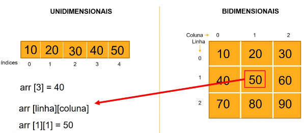

```python
# Criando array unidimensional
```

```python
import numpy as np
```

```python
arr = np.arange(1,11,dtype=int)
```

```python
arr
```

```
array([ 1,  2,  3,  4,  5,  6,  7,  8,  9, 10])
```

```python
# Indexação de arrays unidimensionais
```

```python
arr[4]
```

```
5
```

```python
arr[2:4]
```

```
array([3, 4])
```

```python
arr[2:5]
```

```
array([3, 4, 5])
```

```python
arr[:5]
```

```
array([1, 2, 3, 4, 5])
```

```python
arr[3:]
```

```
array([ 4,  5,  6,  7,  8,  9, 10])
```

```python
# Indexação de arrays bidimensionais
```

```python
arr2 = np.random.randint(10,50,size=(3,3))
```

```python
arr2
```

```
array([[49, 40, 36],
       [37, 11, 36],
       [37, 36, 34]])
```

```python
arr2[1][1]
```

```
11
```

```python
arr2[1][2]
```

```
36
```

```python
arr2[2][0:2]
```

```
array([37, 36])
```

```python
arr3 = np.random.randint(1,101,size=(10,10))
```

```python
arr3
```

```
array([[86, 85, 16, 14, 69, 72, 90, 45, 88, 83],
       [ 1,  9, 79, 41, 51,  6, 73, 49, 90, 96],
       [53, 33,  9, 69, 65, 36,  9, 97, 94, 48],
       [70, 18, 78, 94, 21, 47, 79, 69,  7, 67],
       [75, 52, 17, 83, 81, 57, 53, 81,  4, 38],
       [96, 62, 88, 19, 64, 85, 12, 60, 86, 15],
       [82, 96,  3, 82, 87, 40,  5, 74, 27, 87],
       [35, 12, 43, 24, 35, 84, 68, 84, 14, 76],
       [10, 37, 11, 48, 33, 93, 43, 80, 97, 10],
       [23, 68, 47,  8, 91, 11, 60, 64, 22, 94]])
```

```python
arr3[3][3]
```

```
94
```

```python
arr3[3,3]   # Outra maneira de escrever para obter o mesmo resultado do realizado acima
```

```
94
```

```python
# Agora queremos selecionar os valores: 45,88,83
#                                       49,90,96
#                                       97,94,48
```

```python
arr3[0:3,7:]
```

```
array([[45, 88, 83],
       [49, 90, 96],
       [97, 94, 48]])
```

```python
# Agora queremos selecionar os valores: 9,97,94
#                                       79,69,7
```

```python
arr3[2:4,6:9]
```

```
array([[ 9, 97, 94],
       [79, 69,  7]])
```

```python
 arr3
```

```
array([[86, 85, 16, 14, 69, 72, 90, 45, 88, 83],
       [ 1,  9, 79, 41, 51,  6, 73, 49, 90, 96],
       [53, 33,  9, 69, 65, 36,  9, 97, 94, 48],
       [70, 18, 78, 94, 21, 47, 79, 69,  7, 67],
       [75, 52, 17, 83, 81, 57, 53, 81,  4, 38],
       [96, 62, 88, 19, 64, 85, 12, 60, 86, 15],
       [82, 96,  3, 82, 87, 40,  5, 74, 27, 87],
       [35, 12, 43, 24, 35, 84, 68, 84, 14, 76],
       [10, 37, 11, 48, 33, 93, 43, 80, 97, 10],
       [23, 68, 47,  8, 91, 11, 60, 64, 22, 94]])
```

```python
arr3[[2,4,5]]  # Se colocar valores entre colchetes no local para colocar os índices o retorno será os valores da linha digitada
```

```
array([[53, 33,  9, 69, 65, 36,  9, 97, 94, 48],
       [75, 52, 17, 83, 81, 57, 53, 81,  4, 38],
       [96, 62, 88, 19, 64, 85, 12, 60, 86, 15]])
```

```python
# acima o retorno foi os valores da linha 2 , linha 4 e linha 5. Veja outro exemplo abaixo:
```

```python
arr3[ [8,7,2] ]
```

```
array([[10, 37, 11, 48, 33, 93, 43, 80, 97, 10],
       [35, 12, 43, 24, 35, 84, 68, 84, 14, 76],
       [53, 33,  9, 69, 65, 36,  9, 97, 94, 48]])
```

# AULA 13

### Seleção de arrays

```python
import numpy as np
```

```python
cadastro = np.random.randint(15,51,size=(50,10))
```

```python
cadastro
```

```
array([[17, 27, 42, 17, 35, 32, 32, 23, 17, 34],
       [22, 47, 46, 50, 24, 31, 23, 36, 21, 48],
       [15, 21, 46, 38, 18, 34, 34, 45, 31, 22],
       [17, 49, 42, 43, 26, 18, 23, 28, 27, 40],
       [23, 17, 48, 21, 24, 27, 25, 22, 46, 29],
       [33, 29, 16, 26, 36, 19, 39, 27, 26, 39],
       [31, 25, 24, 34, 37, 43, 33, 49, 37, 27],
       [36, 37, 21, 30, 30, 35, 23, 35, 50, 48],
       [18, 28, 43, 18, 24, 23, 36, 48, 29, 28],
       [29, 27, 18, 41, 18, 45, 41, 24, 33, 33],
       [15, 28, 19, 16, 45, 34, 16, 20, 49, 23],
       [20, 39, 33, 50, 43, 26, 20, 38, 17, 36],
       [23, 44, 16, 19, 16, 21, 27, 37, 28, 32],
       [18, 41, 28, 26, 29, 33, 39, 37, 47, 17],
       [26, 42, 35, 34, 40, 41, 24, 42, 30, 24],
```

[output cut: 35 more lines]

```python
# saber os valores (de forma booleana) que são maiores que 18
```

```python
cadastro_maior18 = cadastro > 18
```

```python
cadastro_maior18
```

```
array([[False,  True,  True, False,  True,  True,  True,  True, False,
         True],
       [ True,  True,  True,  True,  True,  True,  True,  True,  True,
         True],
       [False,  True,  True,  True, False,  True,  True,  True,  True,
         True],
       [False,  True,  True,  True,  True, False,  True,  True,  True,
         True],
       [ True, False,  True,  True,  True,  True,  True,  True,  True,
         True],
       [ True,  True, False,  True,  True,  True,  True,  True,  True,
         True],
       [ True,  True,  True,  True,  True,  True,  True,  True,  True,
         True],
       [ True,  True,  True,  True,  True,  True,  True,  True,  True,
         True],
       [False,  True,  True, False,  True,  True,  True,  True,  True,
         True],
       [ True,  True, False,  True, False,  True,  True,  True,  True,
         True],
       [False,  True,  True, False,  True,  True, False,  True,  True,
         True],
       [ True,  True,  True,  True,  True,  True,  True,  True, False,
         True],
       [ True,  True, False,  True, False,  True,  True,  True,  True,
         True],
       [False,  True,  True,  True,  True,  True,  True,  True,  True,
        False],
       [ True,  True,  True,  True,  True,  True,  True,  True,  True,
         True],
       [ True,  True,  True,  True,  True,  True,  True,  True,  True,
        False],
       [ True,  True,  True,  True,  True,  True,  True,  True,  True,
         True],
       [ True,  True,  True,  True,  True,  True,  True, False,  True,
         True],
       [ True,  True,  True,  True,  True,  True,  True,  True,  True,
         True],
       [ True,  True,  True, False,  True,  True,  True,  True, False,
         True],
```

[output cut: 45 more lines]

```
         True],
       [ True,  True,  True, False, False,  True,  True,  True,  True,
         True],
       [ True,  True, False,  True,  True, False,  True,  True,  True,
         True],
       [ True,  True,  True,  True,  True,  True,  True,  True,  True,
         True],
       [ True,  True,  True,  True, False,  True,  True,  True,  True,
         True],
       [ True, False,  True,  True,  True,  True,  True,  True,  True,
         True],
       [ True,  True,  True,  True,  True,  True,  True, False,  True,
         True],
       [ True,  True,  True,  True,  True,  True, False, False,  True,
         True]])
```

##### A partir do novo array criado é possível selecionar os valores reais no array original.

##### O array que retornou o booleano quando inserido como índice no array original irá retornar apenas os valores TRUE encontrados

##### Veja abaixo:

```python
cadastro[cadastro_maior18]
```

```
array([27, 42, 35, 32, 32, 23, 34, 22, 47, 46, 50, 24, 31, 23, 36, 21, 48,
       21, 46, 38, 34, 34, 45, 31, 22, 49, 42, 43, 26, 23, 28, 27, 40, 23,
       48, 21, 24, 27, 25, 22, 46, 29, 33, 29, 26, 36, 19, 39, 27, 26, 39,
       31, 25, 24, 34, 37, 43, 33, 49, 37, 27, 36, 37, 21, 30, 30, 35, 23,
       35, 50, 48, 28, 43, 24, 23, 36, 48, 29, 28, 29, 27, 41, 45, 41, 24,
       33, 33, 28, 19, 45, 34, 20, 49, 23, 20, 39, 33, 50, 43, 26, 20, 38,
       36, 23, 44, 19, 21, 27, 37, 28, 32, 41, 28, 26, 29, 33, 39, 37, 47,
       26, 42, 35, 34, 40, 41, 24, 42, 30, 24, 42, 23, 43, 48, 42, 48, 47,
       48, 50, 44, 42, 48, 49, 40, 36, 20, 28, 19, 47, 40, 41, 28, 39, 32,
       25, 32, 35, 40, 20, 39, 33, 43, 49, 28, 36, 20, 27, 38, 50, 26, 49,
       25, 43, 20, 45, 22, 39, 38, 25, 38, 41, 26, 31, 43, 21, 40, 24, 38,
       48, 24, 41, 37, 30, 43, 38, 49, 43, 37, 36, 22, 41, 43, 47, 50, 30,
       32, 50, 30, 26, 19, 49, 41, 43, 46, 27, 48, 34, 42, 44, 40, 46, 19,
       29, 31, 20, 28, 35, 25, 45, 25, 48, 23, 39, 21, 48, 26, 25, 28, 27,
       47, 24, 29, 37, 36, 23, 47, 31, 21, 22, 39, 19, 38, 35, 41, 37, 30,
       45, 39, 32, 43, 23, 42, 27, 33, 30, 21, 20, 40, 42, 40, 20, 50, 48,
       50, 47, 40, 25, 28, 21, 36, 31, 31, 41, 26, 32, 46, 40, 41, 30, 41,
       20, 36, 48, 41, 39, 43, 34, 21, 25, 31, 49, 31, 20, 38, 23, 29, 36,
       30, 38, 41, 19, 35, 30, 50, 44, 24, 43, 33, 28, 20, 25, 38, 35, 19,
       26, 22, 29, 25, 45, 20, 20, 50, 37, 39, 39, 30, 46, 44, 26, 31, 45,
       20, 41, 48, 42, 20, 20, 20, 41, 50, 27, 42, 20, 23, 26, 25, 30, 44,
       39, 43, 29, 46, 23, 46, 41, 26, 39, 39, 41, 22, 26, 22, 27, 20, 33,
       48, 31, 49, 29, 24, 32, 33, 42, 34, 30, 30, 29, 50, 48, 47, 34, 30,
       19, 38, 26, 39, 33, 42, 20, 45, 42, 35, 47, 33, 39, 30, 44, 40, 19,
       38, 22, 33, 28, 46, 24, 35, 23, 39, 49, 29, 49, 37, 37, 40, 22, 41,
       27, 49, 41, 31, 26, 36, 39, 24, 21, 30, 32, 22, 28, 49, 25, 42, 42,
       30, 41, 40, 36])
```

##### Daria no mesmo se fizesse: cadastro[ cadastro > 18 ]

```python
cadastro[cadastro > 18]
```

```
array([27, 42, 35, 32, 32, 23, 34, 22, 47, 46, 50, 24, 31, 23, 36, 21, 48,
       21, 46, 38, 34, 34, 45, 31, 22, 49, 42, 43, 26, 23, 28, 27, 40, 23,
       48, 21, 24, 27, 25, 22, 46, 29, 33, 29, 26, 36, 19, 39, 27, 26, 39,
       31, 25, 24, 34, 37, 43, 33, 49, 37, 27, 36, 37, 21, 30, 30, 35, 23,
       35, 50, 48, 28, 43, 24, 23, 36, 48, 29, 28, 29, 27, 41, 45, 41, 24,
       33, 33, 28, 19, 45, 34, 20, 49, 23, 20, 39, 33, 50, 43, 26, 20, 38,
       36, 23, 44, 19, 21, 27, 37, 28, 32, 41, 28, 26, 29, 33, 39, 37, 47,
       26, 42, 35, 34, 40, 41, 24, 42, 30, 24, 42, 23, 43, 48, 42, 48, 47,
       48, 50, 44, 42, 48, 49, 40, 36, 20, 28, 19, 47, 40, 41, 28, 39, 32,
       25, 32, 35, 40, 20, 39, 33, 43, 49, 28, 36, 20, 27, 38, 50, 26, 49,
       25, 43, 20, 45, 22, 39, 38, 25, 38, 41, 26, 31, 43, 21, 40, 24, 38,
       48, 24, 41, 37, 30, 43, 38, 49, 43, 37, 36, 22, 41, 43, 47, 50, 30,
       32, 50, 30, 26, 19, 49, 41, 43, 46, 27, 48, 34, 42, 44, 40, 46, 19,
       29, 31, 20, 28, 35, 25, 45, 25, 48, 23, 39, 21, 48, 26, 25, 28, 27,
       47, 24, 29, 37, 36, 23, 47, 31, 21, 22, 39, 19, 38, 35, 41, 37, 30,
       45, 39, 32, 43, 23, 42, 27, 33, 30, 21, 20, 40, 42, 40, 20, 50, 48,
       50, 47, 40, 25, 28, 21, 36, 31, 31, 41, 26, 32, 46, 40, 41, 30, 41,
       20, 36, 48, 41, 39, 43, 34, 21, 25, 31, 49, 31, 20, 38, 23, 29, 36,
       30, 38, 41, 19, 35, 30, 50, 44, 24, 43, 33, 28, 20, 25, 38, 35, 19,
       26, 22, 29, 25, 45, 20, 20, 50, 37, 39, 39, 30, 46, 44, 26, 31, 45,
       20, 41, 48, 42, 20, 20, 20, 41, 50, 27, 42, 20, 23, 26, 25, 30, 44,
       39, 43, 29, 46, 23, 46, 41, 26, 39, 39, 41, 22, 26, 22, 27, 20, 33,
       48, 31, 49, 29, 24, 32, 33, 42, 34, 30, 30, 29, 50, 48, 47, 34, 30,
       19, 38, 26, 39, 33, 42, 20, 45, 42, 35, 47, 33, 39, 30, 44, 40, 19,
       38, 22, 33, 28, 46, 24, 35, 23, 39, 49, 29, 49, 37, 37, 40, 22, 41,
       27, 49, 41, 31, 26, 36, 39, 24, 21, 30, 32, 22, 28, 49, 25, 42, 42,
       30, 41, 40, 36])
```

```python
# Quantos números tem no array cadastro_maior18:
```

```python
cadastro_maior18.sum() #No booleano false=0 e true=1 então ao somar tudo ocorrerá a soma dos números um que é o TRUE da condição
```

```
446
```

```python
# usando a função len() :
```

```python
arr4 = cadastro[cadastro>18]
```

```python
len(arr4)
```

```
446
```

```python
# Há ainda uma OUTRA FORMA :
```

```python
condição = cadastro > 18
```

```python
extraído = np.extract(condição,cadastro)
```

```python
extraído
```

```
array([27, 42, 35, 32, 32, 23, 34, 22, 47, 46, 50, 24, 31, 23, 36, 21, 48,
       21, 46, 38, 34, 34, 45, 31, 22, 49, 42, 43, 26, 23, 28, 27, 40, 23,
       48, 21, 24, 27, 25, 22, 46, 29, 33, 29, 26, 36, 19, 39, 27, 26, 39,
       31, 25, 24, 34, 37, 43, 33, 49, 37, 27, 36, 37, 21, 30, 30, 35, 23,
       35, 50, 48, 28, 43, 24, 23, 36, 48, 29, 28, 29, 27, 41, 45, 41, 24,
       33, 33, 28, 19, 45, 34, 20, 49, 23, 20, 39, 33, 50, 43, 26, 20, 38,
       36, 23, 44, 19, 21, 27, 37, 28, 32, 41, 28, 26, 29, 33, 39, 37, 47,
       26, 42, 35, 34, 40, 41, 24, 42, 30, 24, 42, 23, 43, 48, 42, 48, 47,
       48, 50, 44, 42, 48, 49, 40, 36, 20, 28, 19, 47, 40, 41, 28, 39, 32,
       25, 32, 35, 40, 20, 39, 33, 43, 49, 28, 36, 20, 27, 38, 50, 26, 49,
       25, 43, 20, 45, 22, 39, 38, 25, 38, 41, 26, 31, 43, 21, 40, 24, 38,
       48, 24, 41, 37, 30, 43, 38, 49, 43, 37, 36, 22, 41, 43, 47, 50, 30,
       32, 50, 30, 26, 19, 49, 41, 43, 46, 27, 48, 34, 42, 44, 40, 46, 19,
       29, 31, 20, 28, 35, 25, 45, 25, 48, 23, 39, 21, 48, 26, 25, 28, 27,
       47, 24, 29, 37, 36, 23, 47, 31, 21, 22, 39, 19, 38, 35, 41, 37, 30,
       45, 39, 32, 43, 23, 42, 27, 33, 30, 21, 20, 40, 42, 40, 20, 50, 48,
       50, 47, 40, 25, 28, 21, 36, 31, 31, 41, 26, 32, 46, 40, 41, 30, 41,
       20, 36, 48, 41, 39, 43, 34, 21, 25, 31, 49, 31, 20, 38, 23, 29, 36,
       30, 38, 41, 19, 35, 30, 50, 44, 24, 43, 33, 28, 20, 25, 38, 35, 19,
       26, 22, 29, 25, 45, 20, 20, 50, 37, 39, 39, 30, 46, 44, 26, 31, 45,
       20, 41, 48, 42, 20, 20, 20, 41, 50, 27, 42, 20, 23, 26, 25, 30, 44,
       39, 43, 29, 46, 23, 46, 41, 26, 39, 39, 41, 22, 26, 22, 27, 20, 33,
       48, 31, 49, 29, 24, 32, 33, 42, 34, 30, 30, 29, 50, 48, 47, 34, 30,
       19, 38, 26, 39, 33, 42, 20, 45, 42, 35, 47, 33, 39, 30, 44, 40, 19,
       38, 22, 33, 28, 46, 24, 35, 23, 39, 49, 29, 49, 37, 37, 40, 22, 41,
       27, 49, 41, 31, 26, 36, 39, 24, 21, 30, 32, 22, 28, 49, 25, 42, 42,
       30, 41, 40, 36])
```

```python
len(extraído)
```

```
446
```

# AULA 14

### Pandas

##### Pandas fornece estrutura de dados de alto desempenho, ferramentas e funções úteis na análise de dados.

##### É através do Pandas que importamos dados, seja da internet ou de um arquivo .csv

##### Apresenta-se em forma de COLUNAS e podem conter variáveis de diversos tipos, diferente dos arrays do Numpy que só eram números, além disso os índices podem ser alterados de qualquer maneira.

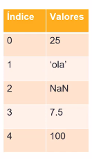

```python
import pandas as pd
import numpy as np
```

```python
# Séries a partir de uma lista
```

```python
lista = [10,20,30,40,50]
```

```python
series1 = pd.Series(lista)  # A série criada a partir da lista faz que os índices da lista sejam colocados em uma coluna relacionada com seu valor
```

```python
series1
```

```
0    10
1    20
2    30
3    40
4    50
dtype: int64
```

```python
series1[1]
```

```
20
```

```python
# Séries a partir de um dicionário
```

```python
dicionario = {'telefone':'9999999', 'telefone2':'5555555','telefone3':'4444444'}
```

```python
series2 = pd.Series(dicionario)   # A série criada a partir de um dicionário faz que as CHAVES do dicionário sejam TRANSFORMADOS EM ÍNDICES, mas os índices numéricos ainda existem.
```

```python
series2
```

```
telefone     9999999
telefone2    5555555
telefone3    4444444
dtype: object
```

```python
 # Obtendo valor pelo índice numérico:
```

```python
series2[2]
```

```
'4444444'
```

```python
# Obtendo valor pelo nome da chave:
```

```python
series2['telefone3']
```

```
'4444444'
```

```python
# Séries a partir de um array
```

```python
arr = np.array( [10,20,30,40,50] )
```

```python
series3 = pd.Series(arr)
```

```python
series3
```

```
0    10
1    20
2    30
3    40
4    50
dtype: int32
```

```python
series4 = pd.Series( [100,200,300,400,500] )
```

```python
series4
```

```
0    100
1    200
2    300
3    400
4    500
dtype: int64
```

```python
series5 = pd.Series( [1,2,3,4], index=['Brasil','USA','Argentina','Chile'])
```

```python
series5
```

```
Brasil       1
USA          2
Argentina    3
Chile        4
dtype: int64
```

```python
lista = [5,6,7,8]
label = ['Portugal','Itália','França','Alemanha']
```

```python
series6 = pd.Series(data=lista, index=label)
```

```python
series6
```

```
Portugal    5
Itália      6
França      7
Alemanha    8
dtype: int64
```

```python
series7 = pd.Series(data=[2,4,6,8], index=['Uruguai','Mexico','Irlanda','Austrália'])
```

```python
series7
```

```
Uruguai      2
Mexico       4
Irlanda      6
Austrália    8
dtype: int64
```

```python
series7 + series6
```

```
Alemanha    NaN
Austrália   NaN
França      NaN
Irlanda     NaN
Itália      NaN
Mexico      NaN
Portugal    NaN
Uruguai     NaN
dtype: float64
```

```python
# A operação acima não conseguiu retornar nada porque não havia itens em comum
```

```python
# Construindo uma série que contenha algo em comum:
```

```python
series8 = pd.Series([12,13,14,15],index=('Alemanha','Irlanda','México','Itália'))
```

```python
series8
```

```
Alemanha    12
Irlanda     13
México      14
Itália      15
dtype: int64
```

```python
series6+series8  # Itália e Alemanha estão em series6 e series8, portanto foi somado o valor assiciado a esses países
```

```
Alemanha    20.0
França       NaN
Irlanda      NaN
Itália      21.0
México       NaN
Portugal     NaN
dtype: float64
```

# AULA 15

### Pandas Dataframes

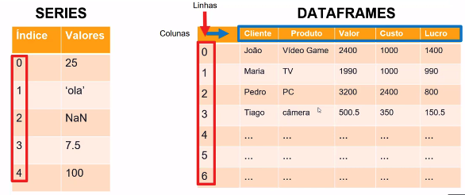

```python
import pandas as pd
import numpy as np
```

```python
# Criação de Dataframes a partir de um array
```

```python
arr = np.random.randint(10,55,size=(4,4))
```

```python
arr
```

```
array([[13, 13, 15, 41],
       [53, 11, 22, 27],
       [19, 43, 29, 36],
       [19, 47, 39, 50]])
```

```python
df1 = pd.DataFrame(data = arr, index = ['A','B','C','D'], columns = ['W','X','Y','Z'])
```

```python
df1
```

|  | W | X | Y | Z |
| --- | --- | --- | --- | --- |
| A | 13 | 13 | 15 | 41 |
| B | 53 | 11 | 22 | 27 |
| C | 19 | 43 | 29 | 36 |
| D | 19 | 47 | 39 | 50 |

```python
# Criação de Dataframes a partir de listas (É preciso listas dentro de listas, porque uma lista só retorna uma simples série)
```

```python
lista = [10,20,30,40,50]
```

```python
df2 = pd.DataFrame(data=lista)
```

```python
df2   # É uma série
```

|  | 0 |
| --- | --- |
| 0 | 10 |
| 1 | 20 |
| 2 | 30 |
| 3 | 40 |
| 4 | 50 |

```python
lista2 = [ [10,20,30,40,50],[60,70,80,90,100],[110,120,130,140,150] ]
```

```python
df_2= pd.DataFrame(data=lista2, index=['A','B','C'], columns=['V','W','X','Y','Z'])
```

```python
df_2
```

|  | V | W | X | Y | Z |
| --- | --- | --- | --- | --- | --- |
| A | 10 | 20 | 30 | 40 | 50 |
| B | 60 | 70 | 80 | 90 | 100 |
| C | 110 | 120 | 130 | 140 | 150 |

```python
# Criação de Dataframes através de um dicionário
```

```python
# Os valores de uma chave pode ser uma LISTA
```

```python
# No exemplo abaixo os valores de 'Preço' precisam corresponder exatamente ao valores de 'Produto'. Videogame/2600, PC/2450, etc
```

```python
dados = {'Produtos':['VideoGame','PC','teclado', 'mouse','microfone'], 'Preço':[2600,2450.90,99.90,75,129.90]}
```

```python
dados
```

```
{'Produtos': ['VideoGame', 'PC', 'teclado', 'mouse', 'microfone'],
 'Preço': [2600, 2450.9, 99.9, 75, 129.9]}
```

```python
df3 = pd.DataFrame( data=dados )
```

```python
df3
```

|  | Produtos | Preço |
| --- | --- | --- |
| 0 | VideoGame | 2600.0 |
| 1 | PC | 2450.9 |
| 2 | teclado | 99.9 |
| 3 | mouse | 75.0 |
| 4 | microfone | 129.9 |

```python
# Adicionando colunas:
```

```python
df3['Custo'] = [1900,2000,40,56.50,95.4]
```

```python
df3
```

|  | Produtos | Preço | Custo |
| --- | --- | --- | --- |
| 0 | VideoGame | 2600.0 | 1900.0 |
| 1 | PC | 2450.9 | 2000.0 |
| 2 | teclado | 99.9 | 40.0 |
| 3 | mouse | 75.0 | 56.5 |
| 4 | microfone | 129.9 | 95.4 |

```python
df3['Lucro'] = df3['Preço'] - df3['Custo']
```

```python
df3
```

|  | Produtos | Preço | Custo | Lucro |
| --- | --- | --- | --- | --- |
| 0 | VideoGame | 2600.0 | 1900.0 | 700.0 |
| 1 | PC | 2450.9 | 2000.0 | 450.9 |
| 2 | teclado | 99.9 | 40.0 | 59.9 |
| 3 | mouse | 75.0 | 56.5 | 18.5 |
| 4 | microfone | 129.9 | 95.4 | 34.5 |

# AULA 16

### Indexação e Seleção de Dataframes

```python
import pandas as pd
import numpy as np

np.random.seed(100)  # Esse comando é só para que os números randômicos fiquem igual ao do exemplo da aula
```

```python
indices = ['Janeiro', 'Março', 'Maio','Julho','Agosto','Outubro','Dezembro']  # Meses com 31 dias
```

```python
colunas = np.arange(1,32)  # Criação de um array (31 dias)
```

```python
colunas
```

```
array([ 1,  2,  3,  4,  5,  6,  7,  8,  9, 10, 11, 12, 13, 14, 15, 16, 17,
       18, 19, 20, 21, 22, 23, 24, 25, 26, 27, 28, 29, 30, 31])
```

```python
dados = np.random.randint(492,2050, size=(7,31))  # size precisa ser condizente com o número de linhas e colunas
```

```python
dados
```

```
array([[2036, 1284,  571,  842,  545, 2042, 1294, 1501, 1244,  772, 1744,
        1832, 1404, 2023, 1609,  578,  878,  907, 1389, 1657, 1249, 1104,
        1520, 1095, 1327,  627,  541, 1947,  809, 1274, 1459],
       [1255, 1852,  494, 1381, 1109,  970, 1919,  555, 1697,  775, 1754,
        1885, 1436, 1819, 1298,  664,  766,  684, 1444, 1422,  929,  765,
        2041, 1110, 1546,  509, 1569,  560,  980, 1863,  967],
       [1185, 1338, 1516,  505, 1701, 1976,  854,  623, 1074, 1728,  886,
        1731, 2018,  987, 1135, 1365, 1692, 1696,  528, 1331,  530, 1730,
        1610, 1230, 1686, 1344,  587, 1592,  806,  594, 1430],
       [ 898, 1772, 1254,  718, 1407,  688,  938, 1310, 1968,  911,  899,
        1257, 2037, 1436, 2012,  901, 1954,  754, 1638, 1702, 1811,  778,
        1381, 1070,  735, 1412,  931,  765, 1305, 2001,  581],
       [ 921, 1295, 1532, 2040, 1982, 1113, 1583,  712, 1739, 1280,  630,
        1268,  965, 1204, 1930, 1505, 1865, 1379, 1048, 1761, 1573,  875,
        1260, 1186, 1480, 1905, 1951,  838,  526,  943, 1354],
       [1186, 1593,  704,  877, 1530, 1805,  640,  660, 1993,  934, 1288,
        1214, 1994, 1006, 1067, 1373, 1646, 1731,  637, 1753, 1766,  969,
        1228,  566, 1953, 1583, 1160, 1598, 1490, 1917, 1145],
       [1085, 1377, 1285, 1710, 1147,  856,  614,  503, 1105, 1496,  530,
        1315,  805,  579, 1183, 1246,  998, 1185, 1197, 1814,  664,  636,
        1698,  675,  575,  994, 1872, 1252, 1250, 1505,  605]])
```

```python
df = pd.DataFrame(data=dados, index=indices, columns=colunas)
```

```python
df
```

|  | 1 | 2 | 3 | 4 | 5 | 6 | 7 | 8 | 9 | 10 | ... | 22 | 23 | 24 | 25 | 26 | 27 | 28 | 29 | 30 | 31 |
| --- | --- | --- | --- | --- | --- | --- | --- | --- | --- | --- | --- | --- | --- | --- | --- | --- | --- | --- | --- | --- | --- |
| Janeiro | 2036 | 1284 | 571 | 842 | 545 | 2042 | 1294 | 1501 | 1244 | 772 | ... | 1104 | 1520 | 1095 | 1327 | 627 | 541 | 1947 | 809 | 1274 | 1459 |
| Março | 1255 | 1852 | 494 | 1381 | 1109 | 970 | 1919 | 555 | 1697 | 775 | ... | 765 | 2041 | 1110 | 1546 | 509 | 1569 | 560 | 980 | 1863 | 967 |
| Maio | 1185 | 1338 | 1516 | 505 | 1701 | 1976 | 854 | 623 | 1074 | 1728 | ... | 1730 | 1610 | 1230 | 1686 | 1344 | 587 | 1592 | 806 | 594 | 1430 |
| Julho | 898 | 1772 | 1254 | 718 | 1407 | 688 | 938 | 1310 | 1968 | 911 | ... | 778 | 1381 | 1070 | 735 | 1412 | 931 | 765 | 1305 | 2001 | 581 |
| Agosto | 921 | 1295 | 1532 | 2040 | 1982 | 1113 | 1583 | 712 | 1739 | 1280 | ... | 875 | 1260 | 1186 | 1480 | 1905 | 1951 | 838 | 526 | 943 | 1354 |
| Outubro | 1186 | 1593 | 704 | 877 | 1530 | 1805 | 640 | 660 | 1993 | 934 | ... | 969 | 1228 | 566 | 1953 | 1583 | 1160 | 1598 | 1490 | 1917 | 1145 |
| Dezembro | 1085 | 1377 | 1285 | 1710 | 1147 | 856 | 614 | 503 | 1105 | 1496 | ... | 636 | 1698 | 675 | 575 | 994 | 1872 | 1252 | 1250 | 1505 | 605 |

7 rows × 31 columns

## IMPORTANTE

  Podemos também passar listas dentro de listas tanto no .loc quanto no .iloc: df.loc[ [indice1,indice2,indice3,etc],[coluna1,coluna2,coluna3,etc] ]

```python
# Quanto vendeu no dia 10 de todos os meses ?
```

```python
df[10]
```

```
Janeiro      772
Março        775
Maio        1728
Julho        911
Agosto      1280
Outubro      934
Dezembro    1496
Name: 10, dtype: int32
```

```python
# Quanto vendeu no dia 10, 20 e 30 de todos os meses ?
```

```python
df[[10,20,30]]
```

|  | 10 | 20 | 30 |
| --- | --- | --- | --- |
| Janeiro | 772 | 1657 | 1274 |
| Março | 775 | 1422 | 1863 |
| Maio | 1728 | 1331 | 594 |
| Julho | 911 | 1702 | 2001 |
| Agosto | 1280 | 1761 | 943 |
| Outubro | 934 | 1753 | 1917 |
| Dezembro | 1496 | 1814 | 1505 |

```python
# Quanto vendeu no dia 15 de Março ?
```

```python
df[15][1]  # ou df[15]['Março']
```

```
1298
```

```python
# Quanto vendeu nos meses Janeiro, Março e Maio ?
```

```python
df[0:3]
```

|  | 1 | 2 | 3 | 4 | 5 | 6 | 7 | 8 | 9 | 10 | ... | 22 | 23 | 24 | 25 | 26 | 27 | 28 | 29 | 30 | 31 |
| --- | --- | --- | --- | --- | --- | --- | --- | --- | --- | --- | --- | --- | --- | --- | --- | --- | --- | --- | --- | --- | --- |
| Janeiro | 2036 | 1284 | 571 | 842 | 545 | 2042 | 1294 | 1501 | 1244 | 772 | ... | 1104 | 1520 | 1095 | 1327 | 627 | 541 | 1947 | 809 | 1274 | 1459 |
| Março | 1255 | 1852 | 494 | 1381 | 1109 | 970 | 1919 | 555 | 1697 | 775 | ... | 765 | 2041 | 1110 | 1546 | 509 | 1569 | 560 | 980 | 1863 | 967 |
| Maio | 1185 | 1338 | 1516 | 505 | 1701 | 1976 | 854 | 623 | 1074 | 1728 | ... | 1730 | 1610 | 1230 | 1686 | 1344 | 587 | 1592 | 806 | 594 | 1430 |

3 rows × 31 columns

```python
# Quanto vendeu nos meses de Julho, Agosto e Outubro nos dias 25 a 31
```

```python
df.loc[ ['Julho','Agosto','Outubro'],[25,26,27,28,29,30,31] ]
```

|  | 25 | 26 | 27 | 28 | 29 | 30 | 31 |
| --- | --- | --- | --- | --- | --- | --- | --- |
| Julho | 735 | 1412 | 931 | 765 | 1305 | 2001 | 581 |
| Agosto | 1480 | 1905 | 1951 | 838 | 526 | 943 | 1354 |
| Outubro | 1953 | 1583 | 1160 | 1598 | 1490 | 1917 | 1145 |

```python
# Fazendo o mesmo com o .iloc
```

```python
df.iloc[ [3,4,5],[24,25,26,27,28,29,30] ]
```

|  | 25 | 26 | 27 | 28 | 29 | 30 | 31 |
| --- | --- | --- | --- | --- | --- | --- | --- |
| Julho | 735 | 1412 | 931 | 765 | 1305 | 2001 | 581 |
| Agosto | 1480 | 1905 | 1951 | 838 | 526 | 943 | 1354 |
| Outubro | 1953 | 1583 | 1160 | 1598 | 1490 | 1917 | 1145 |